# Estudis d'Informàtica, Multimedia i Telecomunicacions

# Mineria de dades: PAC1

Autor: Arnau Garcia Rodríguez

Octubre 2023

# 1 Exercici 1

El projecte de mineria de dades que tractarem en aquest apartat consisteix en **l’estudi de dades sobre accidents laborals a una empresa per a poder aplicar mesures preventives.**

## 1.1 Definició de la tasca de mineria de dades

A la primera fase, la tasca principal serà **definir quin es l’objectiu del nostre projecte de mineria de dades**. Generalment, s’adequa a un dels següents:

- Trobar similituds i agrupar objectes semblants
- Classificar grups tenint-los prèviaments definits
- Predir allò que ens interessi
- Adquirir coneixement descriptiu, és a dir, trobar relacions significatievs entre variables
- Otenir models que expliquin per què s’ha dut a terme un comportament determinat.

En aquesta fase també caldrà decidir quin model s’utilitzarà i quins mètodes i eines s’empraran per construir-lo.

Un cop acabada aquesta primera etapa, cal trobar les dades. Aquestes fonts de dades solen obtenir-se de bases de dades de diferents departaments i de bases de dades transaccional, que guarden un històric d’operacios.

## 1.2 Preparació de les dades

Un cop definida la tasca de mineria, cal **preparar les dades** per a poder-les fer servir per obtenir el model desitjat. A grans trets, l’objectiu és que les dades siguin de prou qualitat, necessàries i que estiguin en el format adequat. Les tècniques que ens permetran assegurar aquests aspectes son:

- Neteja: Consisteix en borrar les dades errònies i redundants.
- Transformació: Molts cops trobarem que les dades no estan en el format adequat per a poder utilitzar-les per a crear el model que desitjem.
- Reducció: A partir de certes quantitats de dades els algorismes comencen a reduïr la seva eficiència. L’ideal es treballar amb la mínima quantitat de dades que ens permeti obtenir els mateixos resultats.

## 1.3 Mineria de dades

En començar aquesta tercera fase, es tindrà decidit el model i les dades seran de qualitat. Per tant, caldrà **decidir els mètodes de construcció del model**. Això vol dir trobar el model que millor s’adeqüi a les característiques de les nostres dades, és a dir, començar un procés de cerca.

Al final d’aquestra fase tindrem un model que representa un coneixement sobre el domini estudiat. En aquest apunt, cal avaluar-lo mitjançant conjunts de dades que provenen del mateix conjunt incial. Un s’utilitzarà per avaluar-lo, l’altre per validar-l i l’altre per construir-lo. Finalment, un cop avaluat i es tingui la certesa de que el model compleix el nivell de qualitat requerit, cal interpretar-lo i extreure la informació al coneixement.

## 1.4 Integració

L’última fase consisteix en integrar en els processos del sistema d’informació els resultats del model trobat. Aquest model caldrà traduirlo al llenguatge de programació corresponent.

# 2 Exercici 2

A partir de dades extretes d’un sistema d’anàlisi de mortalitat de l’any 2010 i facilitades pel National Highway Traffic Safety Administration, amb informació sobre la seguretat a les carreteres, passarem per cadascuna de les etapes i tasques prèvies a la generació d’un model de mineria de dades. Procurarem fer èmfasi en la gestió de característiques i aprofundir en la relació entre els diversos atributs. L’objectiu és extreure coneixement d’aquestes dades i saber quines condicions fan que un accident sigui greu.

## 2.1 Exploració de les dades

El primer pas és carregar les dades, i a continuació, fer una primera exploració de la dimensionalitat i el tipuis d’informació que ens facilita.

```r
path = 'accident2010.CSV'
accidentData <- read.csv(path, row.names=NULL)
```

```r
structure = str(accidentData)
```

```
## 'data.frame':    30296 obs. of  47 variables:
##  $ STATE   : int  1 1 1 1 1 1 1 1 1 1 ...
##  $ ST_CASE : int  10001 10002 10003 10004 10005 10006 10007 10008 10009 10010 ...
##  $ VE_TOTAL: int  1 1 3 2 2 1 1 1 1 2 ...
##  $ VE_FORMS: int  1 1 3 2 2 1 1 1 1 2 ...
##  $ PEDS    : int  0 0 0 0 0 0 0 0 0 0 ...
##  $ PERSONS : int  2 1 3 2 2 1 2 4 2 4 ...
##  $ COUNTY  : int  81 35 97 115 117 21 97 9 51 113 ...
##  $ CITY    : int  2340 1080 2100 160 0 0 0 0 0 0 ...
##  $ DAY     : int  15 11 14 21 4 1 1 2 2 3 ...
##  $ MONTH   : int  1 1 1 1 1 1 1 1 1 1 ...
##  $ YEAR    : int  2010 2010 2010 2010 2010 2010 2010 2010 2010 2010 ...
##  $ DAY_WEEK: int  6 2 5 5 2 6 6 7 7 1 ...
##  $ HOUR    : int  4 6 15 1 6 5 2 15 9 13 ...
##  $ MINUTE  : int  10 0 10 16 38 34 40 37 55 50 ...
```

[output cut: 33 more lines]

Veiem com a la primera fila del resultat ens indica que disposem de **30296 tuples** i **47 atributs** o característiques.

Utilitzant la documentació auxiliar que tenim hem construÏt un diccionari d’un subconjunt de les característiques disponibles que tenim de les dades, que seran les que estudiarem.

- **ST_CASE** identificador d’accident

**SUBCONJUNT DE DIMENSIONS**

- **FATALS** nombre de morts
- **DRUNK_DR** nombre de conductors beguts
- **VE_TOTAL** nombre de vehicles implicats en total
- **VE_FORMS** nombre de vehicles en moviment implicats
- **PEDS** nombre de vianants implicats
- **PERSONS** nombre ocupants de vehicle implicats
- **STATE** codificació de l’estat
- **MONTH** número de mes de l’any
- **HOUR** hora
- **WEATHER** codi condicions meteorològiques

## 2.2 Preparació de les dades

En aquest apartat, prepararem les dades perquè se’ls puguin aplicar les eines que construiran el model. Les dades resultants d’aquesta etapa hauran de ser de prou qualitat, necessàries i s’hauran de trobar en un format adequat.

### 2.2.1 Neteja

En aquest apartat tractarem les dades nul·les o absents.

Primer buscarem si tenim valors nuls al nostre conjunt de dades.

```r
colSums(is.na(accidentData))
```

```
##    STATE  ST_CASE VE_TOTAL VE_FORMS     PEDS  PERSONS   COUNTY     CITY
##        0        0        0        0        0        0        0        0
##      DAY    MONTH     YEAR DAY_WEEK     HOUR   MINUTE      NHS ROAD_FNC
##        0        0        0        0        0        0        0        0
##    ROUTE  TWAY_ID TWAY_ID2   MILEPT LATITUDE LONGITUD   SP_JUR  HARM_EV
##        0        0        0        0        0        0        0        0
## MAN_COLL  RELJCT1  RELJCT2  TYP_INT REL_ROAD WRK_ZONE LGT_COND WEATHER1
##        0        0        0        0        0        0        0        0
## WEATHER2  WEATHER  SCH_BUS     RAIL NOT_HOUR  NOT_MIN ARR_HOUR  ARR_MIN
##        0        0        0        0        0        0        0        0
##  HOSP_HR  HOSP_MN      CF1      CF2      CF3   FATALS DRUNK_DR
##        0        0        0        0        0        0        0
```

Podem veure com no hi ha cap atribut amb almenys un valor nul.

Un cop comprovat que no tenim cap valor nul, cal veure si existeixen camps buits.

```r
colSums(accidentData=="")
```

```
##    STATE  ST_CASE VE_TOTAL VE_FORMS     PEDS  PERSONS   COUNTY     CITY
##        0        0        0        0        0        0        0        0
##      DAY    MONTH     YEAR DAY_WEEK     HOUR   MINUTE      NHS ROAD_FNC
##        0        0        0        0        0        0        0        0
##    ROUTE  TWAY_ID TWAY_ID2   MILEPT LATITUDE LONGITUD   SP_JUR  HARM_EV
##        0        0    23201        0        0        0        0        0
## MAN_COLL  RELJCT1  RELJCT2  TYP_INT REL_ROAD WRK_ZONE LGT_COND WEATHER1
##        0        0        0        0        0        0        0        0
## WEATHER2  WEATHER  SCH_BUS     RAIL NOT_HOUR  NOT_MIN ARR_HOUR  ARR_MIN
##        0        0        0        0        0        0        0        0
##  HOSP_HR  HOSP_MN      CF1      CF2      CF3   FATALS DRUNK_DR
##        0        0        0        0        0        0        0
```

En aquest resultat, sí que podem veure com el camp TWAY_ID2 té **23201** camps buits. Aquest camp fa referència a la via de trànsit l’any 2004, per el que és una dimensió geogràfica. Els valors en blanc poden generar problemes en el funcionament de certs algorismes durant l’etapa de construcció del model. Des del punt de vista de la gestió de característiques, cal comprovar el percentatge de valors en blanc, i així decidir què fem amb aquest camp.

```r
sum(accidentData$TWAY_ID2=="")/30296*100
```

```
## [1] 76.58107
```

Observem que el percentatge de valors en blanc és d’aproximadament el 77%. Si aquesta dimensió resultés d’interès, caldria plantejar-se si realment es vol tenir en compte donat l’alta proporció de dades buides. Tal com hem indicat a l’etapa d’exploració de les dades, aquesta dimensió no forma part del subconjunt d’interès, per la qual cosa serà eliminada juntament amb la resta de dades prescindibles.

### 2.2.2 Reducció de la dimensionalitat

A continuació, prescindirem de les dimensions que no ens interessen.

```r
if (!require('ggplot2')) install.packages('ggplot2'); library('ggplot2')
if(!require('Rmisc')) install.packages('Rmisc'); library('Rmisc')
if(!require('dplyr')) install.packages('dplyr'); library('dplyr')
if(!require('xfun')) install.packages('xfun'); library('xfun')
```

```r
n = c("FATALS","DRUNK_DR","VE_TOTAL","VE_FORMS","PEDS","PERSONS","STATE","MONTH","HOUR","WEATHER")
accidentDataReduced = accidentData %>% select(all_of(n))
```

Aquesta reducció del nombre de dimensions permetrà millorar l’eficiència a l’hora de continuar fent el preprocessament i en una posterior construcció del model desitjat.

### 2.2.3 Visualització de les característiques

En aquest apartat, descriurem i visualitzarem informació que ens ajudarà a entendre les dades i començar a adquirir coneixement. Primer veurem un primer resum de les dades.

```r
summary(accidentDataReduced)
```

```
##      FATALS          DRUNK_DR        VE_TOTAL         VE_FORMS
##  Min.   : 1.000   Min.   :0.000   Min.   : 1.000   Min.   : 1.000
##  1st Qu.: 1.000   1st Qu.:0.000   1st Qu.: 1.000   1st Qu.: 1.000
##  Median : 1.000   Median :0.000   Median : 1.000   Median : 1.000
##  Mean   : 1.089   Mean   :0.328   Mean   : 1.516   Mean   : 1.481
##  3rd Qu.: 1.000   3rd Qu.:1.000   3rd Qu.: 2.000   3rd Qu.: 2.000
##  Max.   :11.000   Max.   :4.000   Max.   :15.000   Max.   :15.000
##       PEDS           PERSONS          STATE           MONTH
##  Min.   :0.0000   Min.   : 0.00   Min.   : 1.00   Min.   : 1.000
##  1st Qu.:0.0000   1st Qu.: 1.00   1st Qu.:12.00   1st Qu.: 4.000
##  Median :0.0000   Median : 2.00   Median :28.00   Median : 7.000
##  Mean   :0.1809   Mean   : 2.29   Mean   :27.97   Mean   : 6.775
##  3rd Qu.:0.0000   3rd Qu.: 3.00   3rd Qu.:42.00   3rd Qu.:10.000
##  Max.   :8.0000   Max.   :57.00   Max.   :56.00   Max.   :12.000
##       HOUR          WEATHER
##  Min.   : 0.00   Min.   : 1.000
##  1st Qu.: 7.00   1st Qu.: 1.000
##  Median :14.00   Median : 1.000
##  Mean   :13.17   Mean   : 3.067
##  3rd Qu.:18.00   3rd Qu.: 1.000
##  Max.   :99.00   Max.   :99.000
```

D’aquest primer resum, ja podem extreure coneixement molt valuós.

- A tots els accidents hi ha com a mínim una víctima mortal.
- 0,328 conductors beguts per accident.
- 1,515 vehicles implicats per accident
- 2,29 persones implicades per accident

#### 2.2.3.1 Histogrames

Pot resultar interessant veure les dades mitjançant histogrames i fer algunes **observacions**. Començarem amb el nombre de morts i de vehicles implicats.

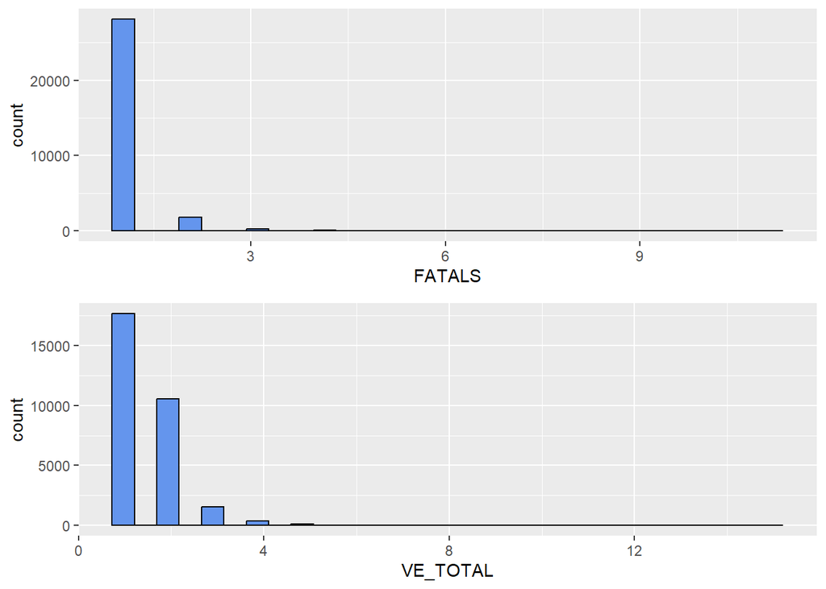

```r
histList<- list()

n = c("FATALS","VE_TOTAL")
accidentDataAux= accidentDataReduced %>% select(all_of(n))
for(i in 1:ncol(accidentDataAux)){
  col <- names(accidentDataAux)[i]
  ggp <- ggplot(accidentDataAux, aes_string(x = col)) +
    geom_histogram(bins = 30, fill = "cornflowerblue", color = "black",ggtittle = "Comptador")
      histList[[i]] <- ggp
}
 multiplot(plotlist = histList, cols = 1)
```

**VE_TOTAL** El mínim de vehicles implicats es 1 i el màxim 15. A la majoria gran d’accidents hi ha un o dos vechicles implicats.

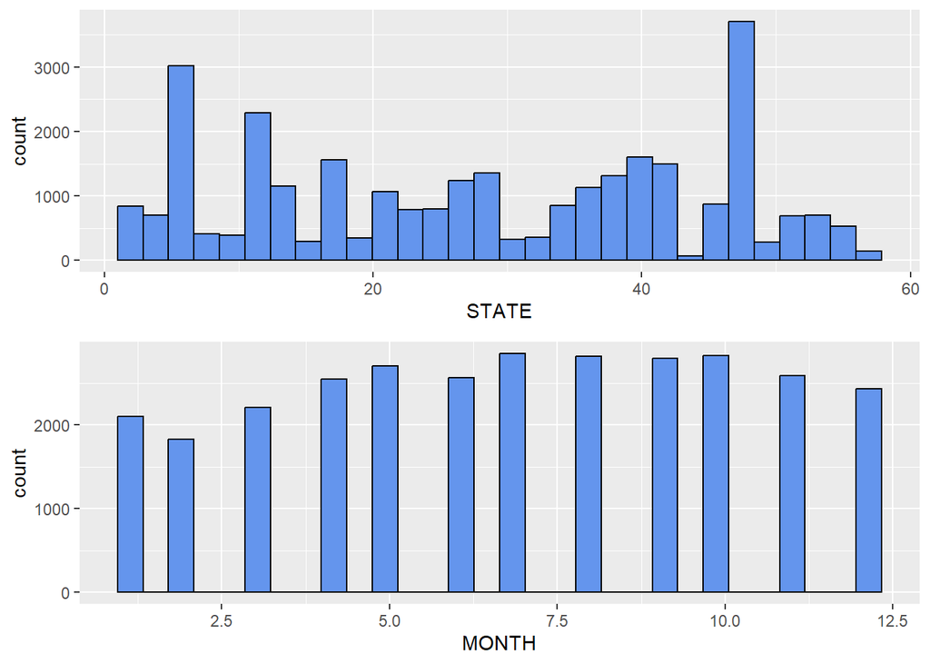

```r
histList<- list()

n = c("STATE","MONTH")
accidentDataAux= accidentDataReduced %>% select(all_of(n))
for(i in 1:ncol(accidentDataAux)){
  col <- names(accidentDataAux)[i]
  ggp <- ggplot(accidentDataAux, aes_string(x = col)) +
    geom_histogram(bins = 30, fill = "cornflowerblue", color = "black",ggtittle = "Comptador")
      histList[[i]] <- ggp
}
 multiplot(plotlist = histList, cols = 1)
```

**STATE**

Observem com hi ha molta diferència en el nombre d’accidents per estat, molt probablement conseqüència de la quantitat de gent que hi viu a cadascun d’ells.

**MONTH**

Fent una ullada al gràfic es pot veure que hi ha una major quantitat d’accidents durant els mesos a l’interval [5 (maig), 12(desembre)].

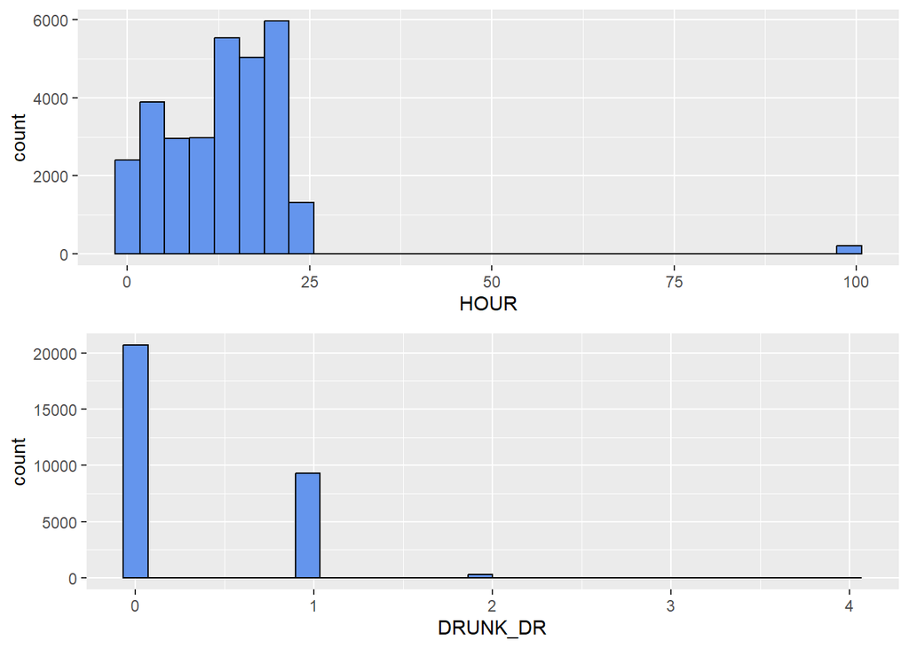

```r
histList<- list()

n = c("HOUR","DRUNK_DR")
accidentDataAux= accidentDataReduced %>% select(all_of(n))
for(i in 1:ncol(accidentDataAux)){
  col <- names(accidentDataAux)[i]
  ggp <- ggplot(accidentDataAux, aes_string(x = col)) +
    geom_histogram(bins = 30, fill = "cornflowerblue", color = "black",ggtittle = "Comptador")
      histList[[i]] <- ggp
}
 multiplot(plotlist = histList, cols = 1)
```

**HOUR** Veiem com augmenta el nombre d’accidents a mesura que passa el dia. Veiem com hi ha hores amb valor 99. Això és a causa del fet que es va decidir afegir un 99 a tots els casos o no es sabia l’hora de l’accident.

#### 2.2.3.2 Relacions entre variables

A continuació mostrarem les correlacions en funció de les morts i dimensions que ens poden ajudar a adquirir coneixement de les condicions que provoquen víctimes mortals:

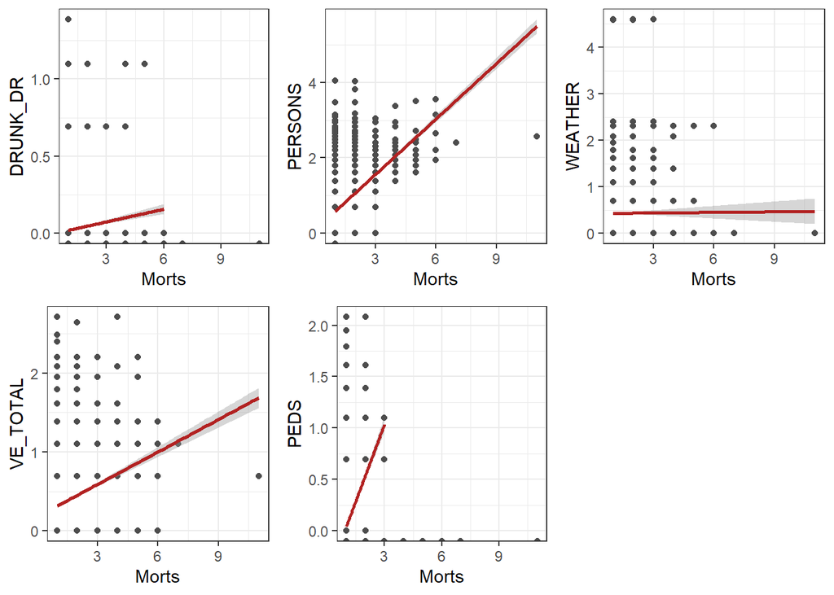

```r
if(!require('Rmisc')) install.packages('Rmisc'); library('Rmisc')

n = c("DRUNK_DR","VE_TOTAL","PERSONS","PEDS","WEATHER")
accidentDataAux= accidentDataReduced %>% select(all_of(n))
histList2<- vector('list', ncol(accidentDataAux))
for(i in seq_along(accidentDataAux)){
  message(i)
histList2[[i]]<-local({
  i<-i
  col <-log(accidentDataAux[[i]])
  ggp<- ggplot(data = accidentDataAux, aes(x = accidentDataReduced$FATALS, y=col)) +
    geom_point(color = "gray30") + geom_smooth(method = lm,color = "firebrick") +
    theme_bw() + xlab("Morts") + ylab(names(accidentDataAux)[i])
  })

}
multiplot(plotlist = histList2, cols = 3)
```

**Observacions**

- Veiem com amb totes les variables, menys la de condició climàtica (WEATHER), augmenta el número de morts a mesura que ho fa la variable.
- La variable de WEATHER, al ser codis de condicions climàtiques, no mostra relació amb la quantitat de víctimes mortals.

Utilitzem les columnes que ens interessen per fer la matriu i la visualitzarem utilitzant la funció corrplot.

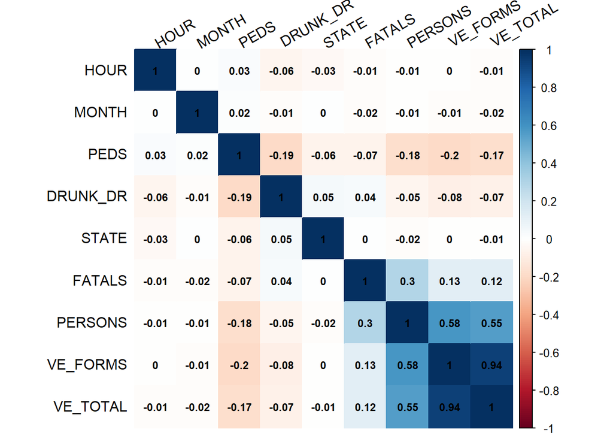

```r
if(!require("corrplot")) install.packages("corrplot"); library("corrplot")
n = c("FATALS","DRUNK_DR","VE_TOTAL","VE_FORMS","PEDS","PERSONS","STATE","MONTH","HOUR")
factors= accidentDataReduced %>% select(all_of(n))
res<-cor(factors)
corrplot(res,method="color",tl.col="black", tl.srt=30, order = "AOE",
   number.cex=0.75,sig.level = 0.01, addCoef.col = "black")
```

Observem un alt grau de correlació entre:

- Vehicles implicats en total (VE_TOTAL) i nombre de vehicles en moviment implicats(VE_FORMS)

Aprofundirem en la correlació entre persones begudes i víctimes mortals, ja que sembla que estiguin menys relacionades del que es podia pensar en un principi. Utilitzarem el mètode **kendall**.

```r
if (!require('tidyverse')) install.packages('tidyverse'); library('tidyverse')
cor.test(x = accidentDataReduced$DRUNK_DR, y = accidentDataReduced$FATALS, method = "kendall")
```

```
##
##  Kendall's rank correlation tau
##
## data:  accidentDataReduced$DRUNK_DR and accidentDataReduced$FATALS
## z = 6.0047, p-value = 1.917e-09
## alternative hypothesis: true tau is not equal to 0
## sample estimates:
##        tau
## 0.03415576
```

Després d’observar el grau de correlació de Kendall, podem dir que el nombre de persones mortes augmenta quan el nombre de conductors beguts és més alt, pero la correlació no és d’un grau tan alt com podiem pensar en un principi. De fet, és tan baix que podria no tenir importància a efectes pràctics.

## 2.3 Transformació de les dades

Com hem vist anteriorment, tenim alguns atributs que estan tan correlacionats que aporten la mateixa informació, com és el cas de VE_TOTAL amb VE_FORMS. En aquests casos, cal eliminar una de les dues característiques.

```r
accidentDataReduced$VE_FORMS<- NULL

str(accidentDataReduced)
```

```
## 'data.frame':    30296 obs. of  9 variables:
##  $ FATALS  : int  1 1 1 1 1 1 2 1 1 1 ...
##  $ DRUNK_DR: int  1 0 0 0 0 0 0 0 0 1 ...
##  $ VE_TOTAL: int  1 1 3 2 2 1 1 1 1 2 ...
##  $ PEDS    : int  0 0 0 0 0 0 0 0 0 0 ...
##  $ PERSONS : int  2 1 3 2 2 1 2 4 2 4 ...
##  $ STATE   : int  1 1 1 1 1 1 1 1 1 1 ...
##  $ MONTH   : int  1 1 1 1 1 1 1 1 1 1 ...
##  $ HOUR    : int  4 6 15 1 6 5 2 15 9 13 ...
##  $ WEATHER : int  1 1 1 2 1 2 2 1 1 1 ...
```

També modificarem els valors que prenen alguns atributs a través de la **Normalització** i la **Discretització**.

### 2.3.1 Discretització

```r
accidentDataAux=subset(accidentDataReduced, accidentDataReduced$MONTH <= 12)

summary(accidentDataAux[,"MONTH"])
```

```
##    Min. 1st Qu.  Median    Mean 3rd Qu.    Max.
##   1.000   4.000   7.000   6.775  10.000  12.000
```

```r
accidentDataAux["trimestre"] <- cut(accidentDataAux$MONTH, breaks = c(1,3,6,9,12), labels = c("Primer","Segon","Tercer","Quart"))
```

Un cop discretitzada la característica, observem com s’agrupen els accidents en trimestres

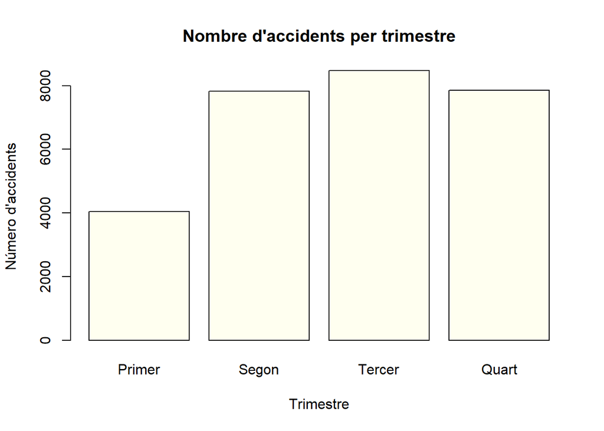

```r
plot(accidentDataAux$trimestre,main="Nombre d'accidents per trimestre",xlab="Trimestre", ylab="Número d'accidents",col = "ivory")
```

Veiem que la major part dels accidents es van produir els tres darrers trimestres de l’any.

Anem a veure com es relaciona aquesta nova variable discretitzada amb els conductors beguts.

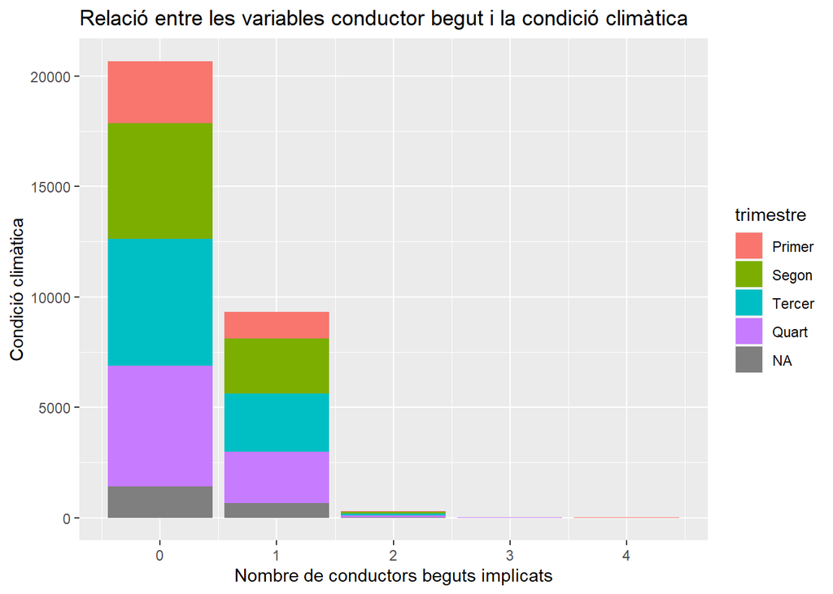

```r
files=dim(accidentDataAux)[1]
ggplot(data=accidentDataAux[1:files,],aes(x=DRUNK_DR,fill=trimestre))+geom_bar()+ggtitle("Relació entre les variables conductor begut i la condició climàtica")+labs(x="Nombre de conductors beguts implicats",y="Condició climàtica")
```

L’única observació que podem fer és la conservació de la proporció de cada trimestre en cadascuna de les columnes.

### 2.3.2 Normalització

Normalitzarem pel màxim i per diferència el nombre de vianants implicats.

```r
accidentDataReduced$PEDS_NM<- (accidentDataReduced$PEDS/max(accidentDataReduced[,"PEDS"]))

accidentDataReduced$PEDS_ND = (accidentDataReduced$PEDS-min(accidentDataReduced$PEDS))/(max(accidentDataReduced$PEDS)-min(accidentDataReduced$PEDS))
```

Un cop normalitzat mitjançant els dos mètodes esmentats, podem comparar els tres histogrames:

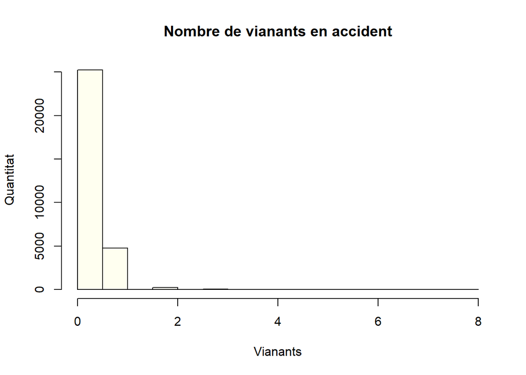

```r
hist(accidentDataReduced$PEDS,xlab="Vianants", col="ivory",ylab="Quantitat", main="Nombre de vianants en accident")
```

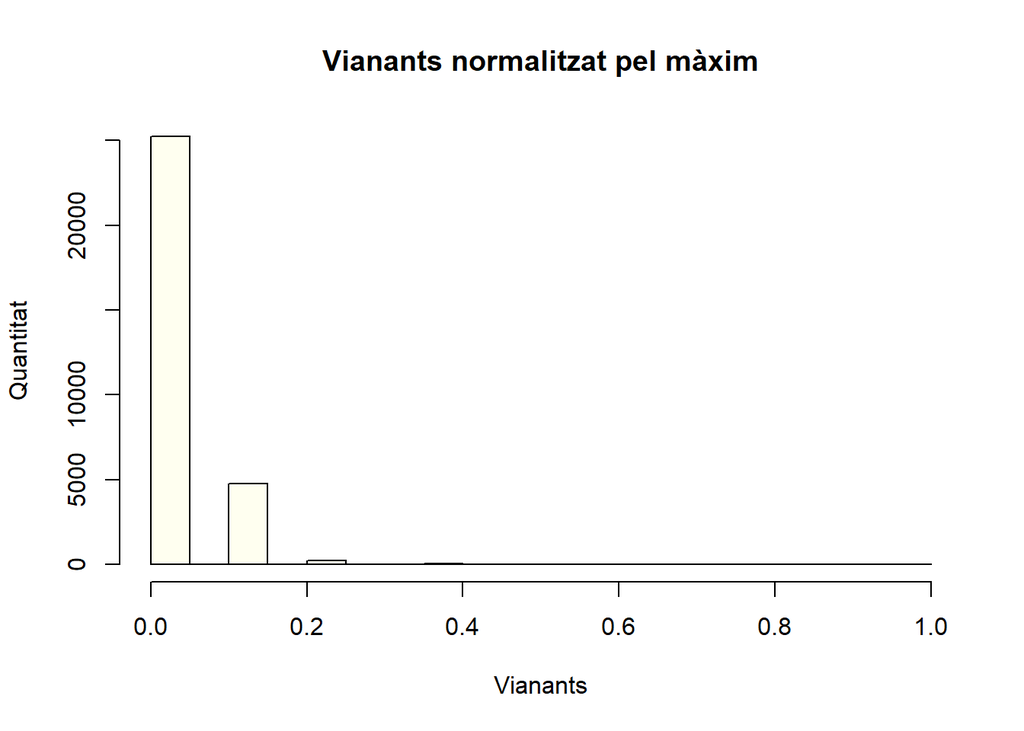

```r
hist(accidentDataReduced$PEDS_NM,xlab="Vianants",ylab="Quantitat",col="ivory", main="Vianants normalitzat pel màxim")
```

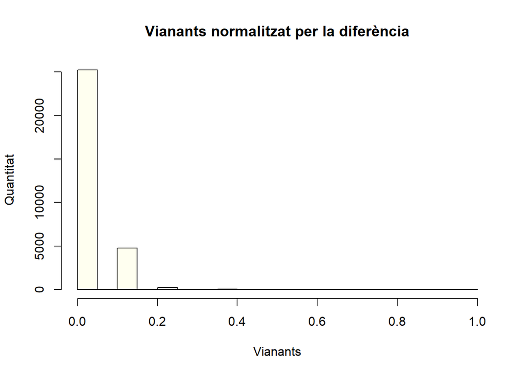

```r
hist(accidentDataReduced$PEDS_ND,xlab="Vianants",ylab="Quantitat", col="ivory", main="Vianants normalitzat per la diferència")
```

Ara normalitzarem totes les nostres dades per la diferència i així assegurarem el bon funcionament del model.

```r
# Definim la funció de normalització
 nor <-function(x) { (x -min(x))/(max(x)-min(x))}
# Guardem un nou dataset normalitzat

accidentData$type<- NULL
n = c("FATALS","DRUNK_DR","VE_TOTAL","PEDS","PERSONS","MONTH")

accidentData<- accidentData %>% select(all_of(n))
accidentData_nor <- as.data.frame(lapply(accidentData, nor))

 head(accidentData_nor)
```

```
##   FATALS DRUNK_DR   VE_TOTAL PEDS    PERSONS MONTH
## 1      0     0.25 0.00000000    0 0.03508772     0
## 2      0     0.00 0.00000000    0 0.01754386     0
## 3      0     0.00 0.14285714    0 0.05263158     0
## 4      0     0.00 0.07142857    0 0.03508772     0
## 5      0     0.00 0.07142857    0 0.03508772     0
## 6      0     0.00 0.00000000    0 0.01754386     0
```

Com a resultat d’aquest procés de normalització, tenim tots els camps normalitzats per la diferència dins la variable **accidentData_nor**.

## 2.4 Procés de PCA

L’anàlisi de components principals (PCA) és una tècnica que ens permetrà treballar amb noves característiques anomenades components, independents entre si. Aquest sistema permet recollir millor la variabilitat perquè està més ben adaptat al joc de dades. A la pràctica, el que farem serà afegir al joc de dades original aquests nous components principals que recullin una variabilitat més alta.

A continuació, escalarem les dades i aplicarem l’anàlisi de components principals:

```r
acc_scale <- scale(accidentData_nor)
pca.acc <- prcomp(acc_scale)
summary(pca.acc)
```

```
## Importance of components:
##                           PC1    PC2    PC3    PC4    PC5     PC6
## Standard deviation     1.3297 1.0824 0.9988 0.9624 0.8483 0.64553
## Proportion of Variance 0.2947 0.1953 0.1663 0.1544 0.1199 0.06945
## Cumulative Proportion  0.2947 0.4900 0.6562 0.8106 0.9305 1.00000
```

Veiem com el primer i segon component principal són els que més expliquen la variabilitat del conjunt de dades, representant el 0.2947 (29.47%) i el 0.1953 (19.53%) respectivament. L’histograma següent mostra de forma visual el pes de cada dimensió sobre el total de dades.

```r
if (!require('factoextra')) install.packages('factoextra'); library('factoextra')
#Els valors propis corresponen a la quantitat de variació explicada per cada component principal (PC).
ev= get_eig(pca.acc)
ev
```

```
##       eigenvalue variance.percent cumulative.variance.percent
## Dim.1  1.7682040        29.470066                    29.47007
## Dim.2  1.1716516        19.527527                    48.99759
## Dim.3  0.9975877        16.626462                    65.62405
## Dim.4  0.9261857        15.436428                    81.06048
## Dim.5  0.7196603        11.994338                    93.05482
## Dim.6  0.4167107         6.945179                   100.00000
```

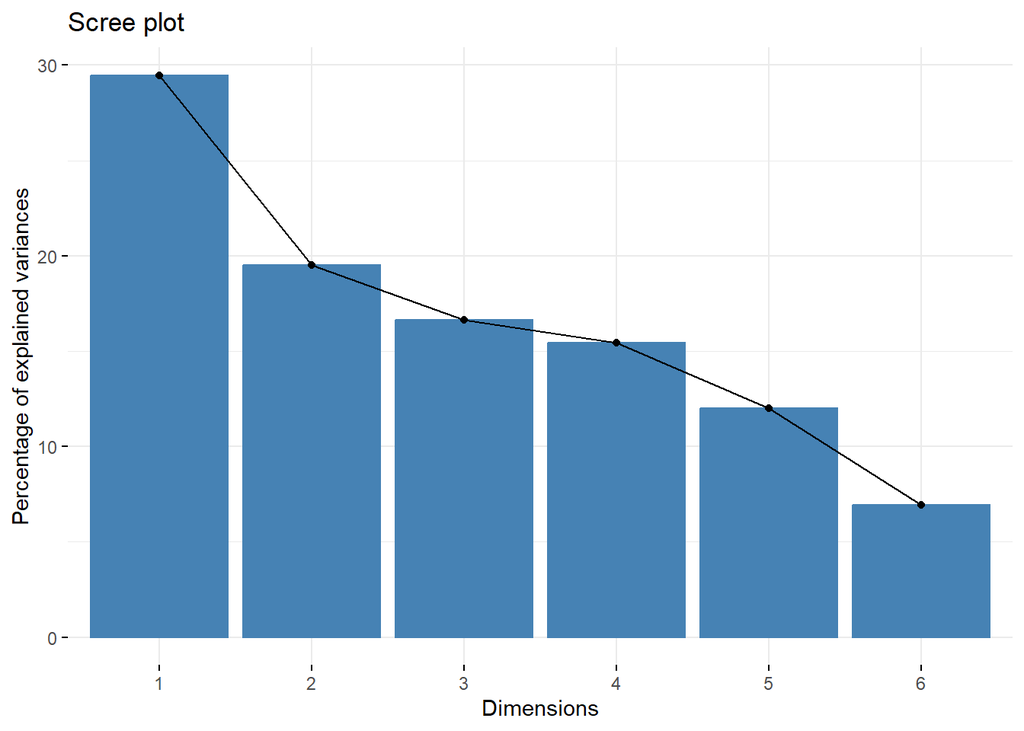

```r
fviz_eig(pca.acc)
```

Farem servir el mètode de Kaiser per escollir les característiques. Aquest mètode es quedarà amb totes les dimensions amb variància superior a 1.

```r
# Calculem les components principals
pca.acc_scale <- prcomp(acc_scale)
# Mostramos la varianza de dichas variables:
var_acc_scale <- pca.acc_scale$sdev^2
head(var_acc_scale)
```

```
## [1] 1.7682040 1.1716516 0.9975877 0.9261857 0.7196603 0.4167107
```

Veient aquestes variàncies, apliquem el mètode Kàiser i ens quedem amb els components 1 i 2.

```r
var <- get_pca_var(pca.acc_scale)
var
```

```
## Principal Component Analysis Results for variables
##  ===================================================
##   Name       Description
## 1 "$coord"   "Coordinates for the variables"
## 2 "$cor"     "Correlations between variables and dimensions"
## 3 "$cos2"    "Cos2 for the variables"
## 4 "$contrib" "contributions of the variables"
```

Els components de get_pca_var() es poden utilitzar en el diagrama de variables de la següent manera:

- **var$coord**: coordenades de variables per crear un diagrama de dispersió.
- **var$cos2**: representa la qualitat de representació de les variables al mapa de factors. Es calcula com les coordenades al quadrat: var.cos2 = var.coord * var.coord.
- **var$contrib**: conté les contribucions (en percentatge) de les variables als components principals. La contribució d’una variable (var) a un determinat component principal és (en percentatge): (var.cos2 * 100) / (cos2 total del component).

```r
#Utilitzem els 3 components principals trobats abans
head(var$coord[,1:2],11)
```

```
##                 Dim.1       Dim.2
## FATALS    0.495163830 -0.04169973
## DRUNK_DR -0.003826473 -0.84277590
## VE_TOTAL  0.786455961  0.18950356
## PEDS     -0.414497653  0.62366468
## PERSONS   0.854605271  0.15439082
## MONTH    -0.048277008  0.10457418
```

### 2.4.1 Qualitat de representació

A continuació, observarem la qualitat de representació de les variables en el mapa de factors.

```r
head(var$cos2[,1:2],11)
```

```
##                 Dim.1       Dim.2
## FATALS   0.2451872188 0.001738868
## DRUNK_DR 0.0000146419 0.710271222
## VE_TOTAL 0.6185129789 0.035911597
## PEDS     0.1718083041 0.388957627
## PERSONS  0.7303501692 0.023836526
## MONTH    0.0023306695 0.010935760
```

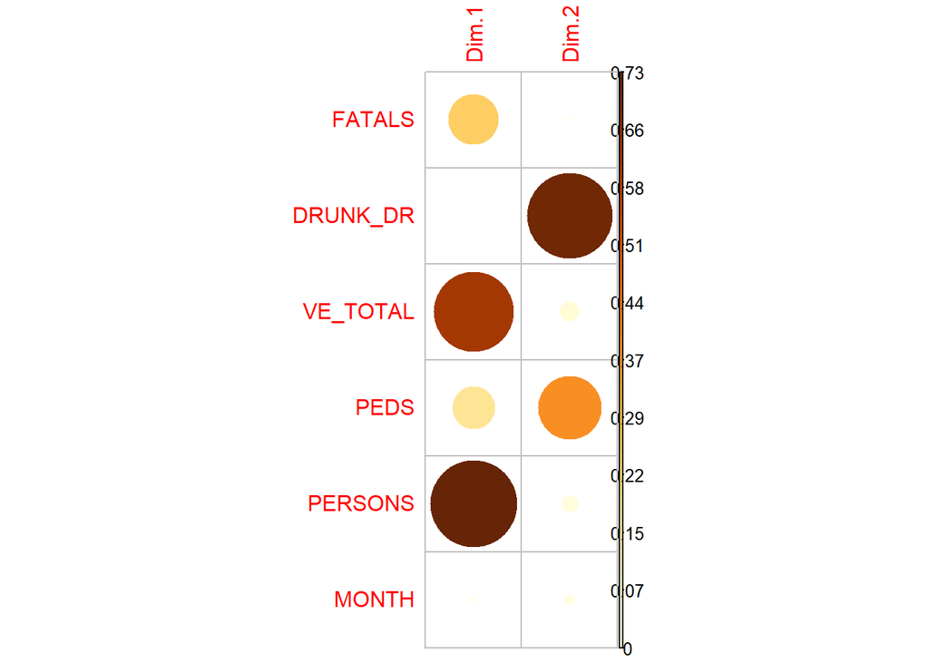

```r
corrplot(var$cos2[,1:2], is.corr=FALSE)
```

Veiem com MONTH no aporta informació a cap dels dos components principals. Això es degut a que està altament relacionada amb la 3a.

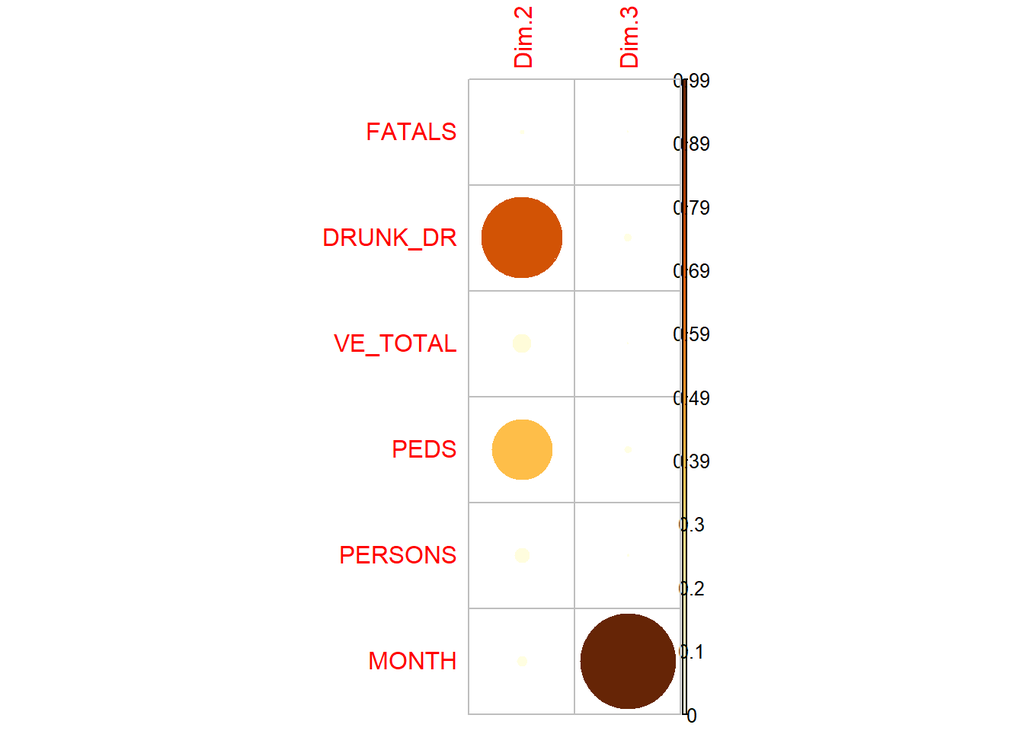

```r
corrplot(var$cos2[,2:3], is.corr=FALSE)
```

A continuació veurem un diagrama de barres que representa amb columnes la qualitat de representació dels dos components principals

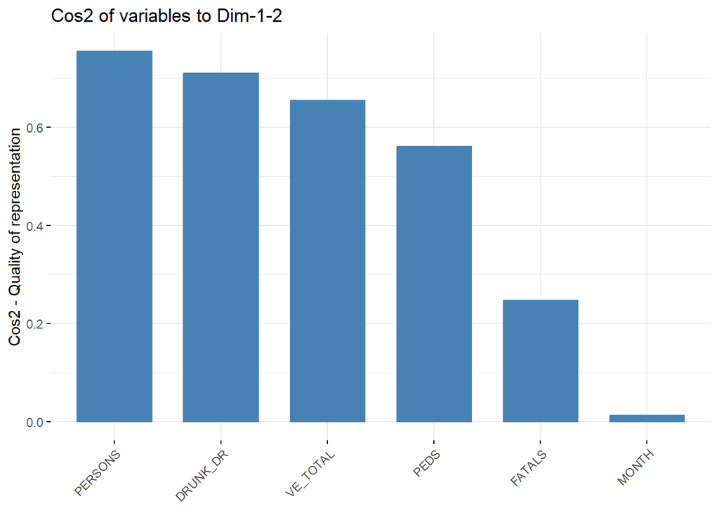

```r
fviz_cos2(pca.acc_scale, choice = "var", axes = 1:2)
```

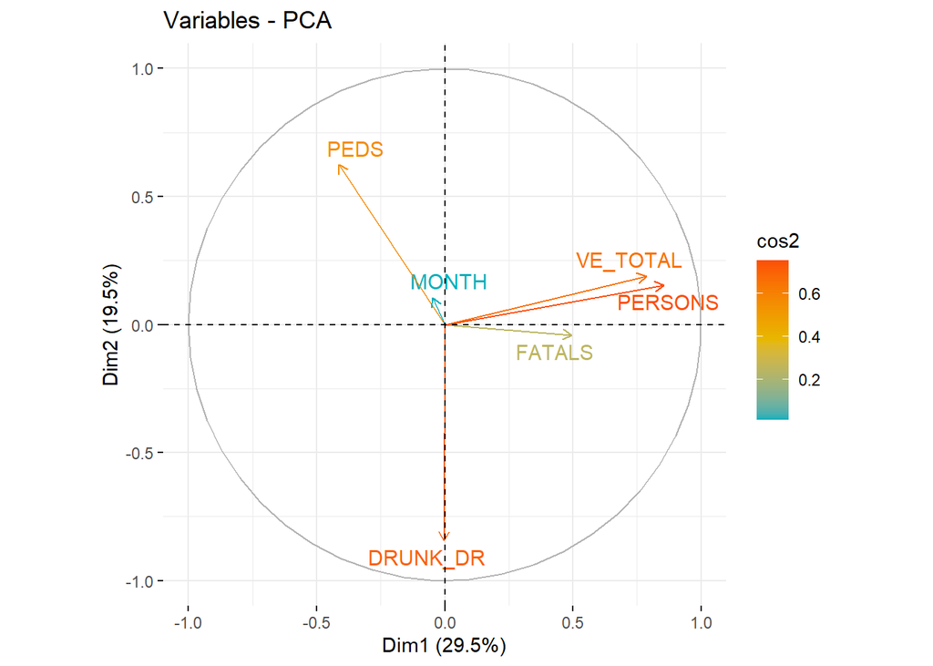

```r
fviz_pca_var(pca.acc_scale,
             col.var = "cos2",
             gradient.cols = c("#00AFBB", "#E7B800", "#FC4E07"),
             repel = TRUE
             )
```

*Conclusions*

Podem observar com la variable MONTH es troba al centre de la trama, pel que no es gaire representativa de la qualitat dels dos components principals. D’altra banda, atributs com PERSONS, VE_TOTAL o DRUNK_DR es troben molt a prop del cercle de correlacions.

### 2.4.2 Contribució

A continuació, observem la contribució (expresada en %) de cadascuna de les característiques als components principals. Aquelles que no contribueixin a la variablitat de les primeres dimensions es podran eliminar per simplificar l’anàlisi.

```r
head(var$contrib[,1:2],11)
```

```
##                 Dim.1      Dim.2
## FATALS   13.866455522  0.1484117
## DRUNK_DR  0.000828066 60.6213674
## VE_TOTAL 34.979730001  3.0650406
## PEDS      9.716543216 33.1973794
## PERSONS  41.304633202  2.0344381
## MONTH     0.131809992  0.9333628
```

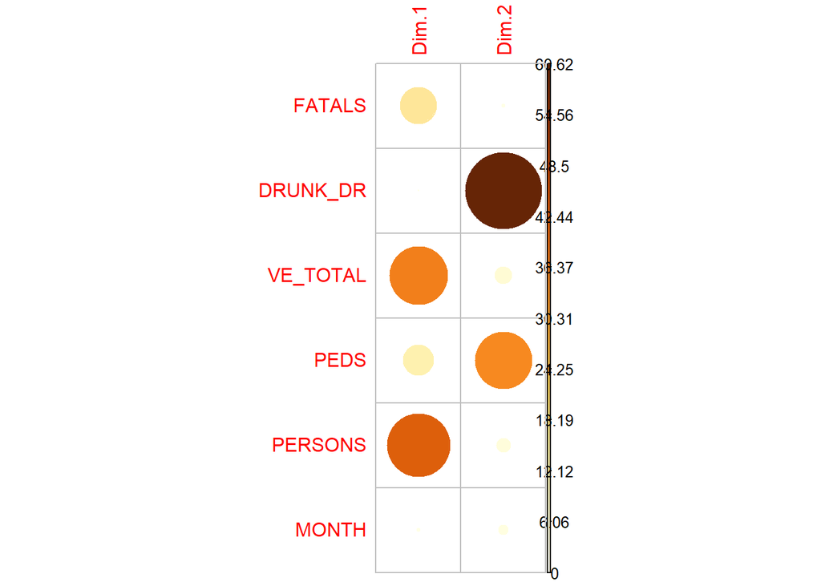

```r
corrplot(var$contrib[,1:2], is.corr=FALSE)
```

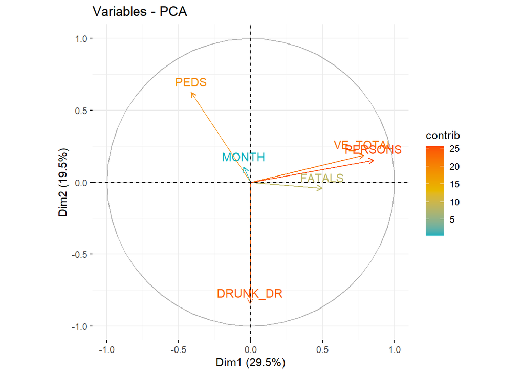

```r
fviz_pca_var(pca.acc_scale, col.var = "contrib",
             gradient.cols = c("#00AFBB", "#E7B800", "#FC4E07")
             )
```

La primera observació que es pot fer i que es veu a simple vista, és que MONTH no contribueix gaire als dos components principals.

D’altra banda, cal tenir en compte que totes aquelles variables que apunten cap al mateix costat, estan correlacionades de forma positiva, y sino, negativa.

Un exemple de **correlació positiva** son el vehicles totals (VE_TOTALS) i el nombre de persones implicades (PERSONS). D’aqui podem extreure la informació que quants més vehicles implicats en l’accident, més persones implicades.

Un exemple de correlació negativa és el nombre de vianants (PEDS) i el nombre de conductors beguts (DRUNK_DR). No sembla que hi hagi una relació de causalitat entre aquestes dues variables, pel que aquesta correlació negativa cal prendre-la simplement com una relació estadística, molt probablement provocada per altres dades.

Aquests nous components o dimensions obtinguts mitjançant el PCA es podrien utilitzar com a indexos de perillositat d’un accident.

## 2.5 Interpretació dels resultats

Hem estudiat un conjunt de dades sobre **accidents de trànsit**, extret del departament de transport dels Estats Units durant l’any **2010**. Aquestes dades contenen informació com el nombre de víctimes mortals, conductors beguts, vehicles implicats, vianants, dates, condicions climàtiques, dimensions geogràfiques, i així fins a 47 atributs. En total, en aquestes dades hi ha enregistrats 30296 accidents mortals.

En el procés de neteja hem vist com en general eren unes dades bastant completes, amb excepcions com ha sigut el cas del camp **TWAY_ID2**. A l’inici s’ha establert que aquest no era un dels camps d’interès, per la qual cosa era una dada prescindible. Hem aprofitat per **reduir la dimensionalitat** del conjunt de dades amb el que estàvem treballat, i hem dut a terme tota l’activitat amb el subconjunt de característiques que hem indicat que ens interessaven a l’inici.

Durant la visualització de les dades de les quals disposàvem, hem vist com tots els accidents tenien com a mínim una víctima mortal. Altres observacions interessants són les diferències respecte a nombre d’accidents entre estats, molt probablement provocades per les diferències demogràfiques entre aquests i que la majoria d’accidents s’han produït als tres últims trimestres de l’any. Aquesta última observació s’ha dut a terme **discretitzant els mesos en trimestres** i eliminant aquelles tuples en les quals no es tenia coneixement del mes.

En últim lloc, hem generat una **nova dimensió mitjançant la tècnica del PCA** que podria ajudar-nos a valorar l’**índex de perillositat i de risc de mortalitat** en un accident de trànsit, ja que està relacionat amb els vehicles implicats, el nombre de persones i les víctimes mortals.